# Lab5

SpicyBois

9/29/2019

# Assignment Details

## Individually

1. For the first, display the distribution of the yearly milk production (in millions of pounds) for your birth-year.
2. Summarise the data for your birth year. Mean, median, max (add amount), min (add amount).

## Team

1. Select all of the states in which at least one of your group members has lived in. If there are less than 5, choose additional states so that you select 5 of them. For these states, plot a yearly time series for the milk production (in millions of pounds). On this plot, display a line showing the average milk produced each year for all states.
2. The year when the most milk was produced in the United States.
3. The year when the least milk was produced in the United States.
4. In 2017, report the 5 states that produced the most milk. (Hint: Use arrange)
5. In 2017, report the 5 states that produced the least milk. (Hint: Use arrange)

# Distribution of Milk Production for our Birth Year (Individual)

## Distribution of the Yearly Milk Production for 1997 (Tyler)

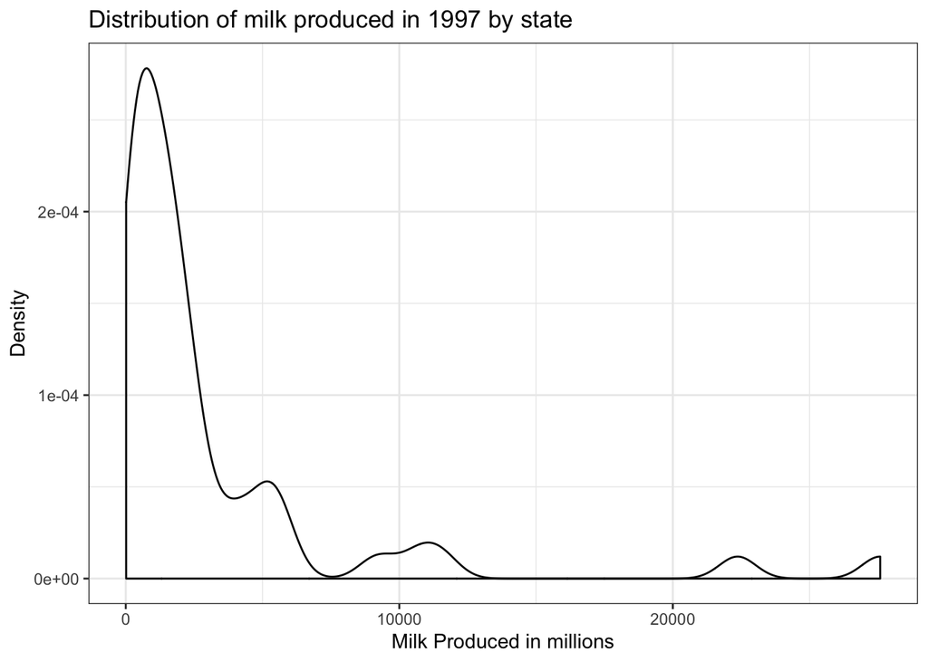

```r
milk1997 <- milk %>%
  filter(year == 1997)

ggplot(data = milk1997, mapping = aes(x = milk_million)) +
         geom_density() +
         theme_bw() +
         labs(title = "Distribution of milk produced in 1997 by state", x = "Milk Produced in millions", y = "Density")
```

```r
milkSummary1997 <- milk1997 %>%
  select(state, milk_million) %>%
  group_by(state) %>%
  summarise(Average = mean(milk_million), Median = median(milk_million), Maximum = max(milk_million), Minimum = min(milk_million)) %>%
  as_tibble

milkSummary1997
```

```
## # A tibble: 50 x 5
##    state       Average Median Maximum Minimum
##    <fct>         <dbl>  <dbl>   <dbl>   <dbl>
##  1 Alabama         418    418     418     418
##  2 Alaska           15     15      15      15
##  3 Arizona        2664   2664    2664    2664
##  4 Arkansas        635    635     635     635
##  5 California    27582  27582   27582   27582
##  6 Colorado       1679   1679    1679    1679
##  7 Connecticut     509    509     509     509
##  8 Delaware        148    148     148     148
##  9 Florida        2476   2476    2476    2476
## 10 Georgia        1488   1488    1488    1488
## # … with 40 more rows
```

## Distribution of the Yearly Milk Production for 1998 (Trent)

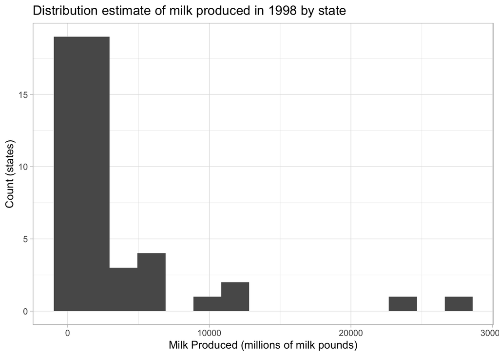

```r
milk1998 <- milk %>%
  filter(year == 1998)

ggplot(data = milk1998, aes(x = milk_million)) +
  geom_histogram(bins = 15) +
  theme_light()+
  labs(title = "Distribution estimate of milk produced in 1998 by state", x = "Milk Produced (millions of milk pounds)", y = "Count (states)")
```

```r
milkcor98 <- milk %>% select(state, year, milk_million) %>% group_by(state) %>%
  summarise(Average = mean(milk_million), Median = median(milk_million), Max = max(milk_million), Min = min(milk_million)) %>%
  as_tibble()
milkcor98
```

```
## # A tibble: 50 x 5
##    state       Average Median   Max   Min
##    <fct>         <dbl>  <dbl> <dbl> <dbl>
##  1 Alabama       433.    501    820    89
##  2 Alaska         14.1    14     35     3
##  3 Arizona      2436.   2005   5010   585
##  4 Arkansas      543.    702    848    79
##  5 California  25410.  24079  42339  9457
##  6 Colorado     1796.   1502.  4189   835
##  7 Connecticut   512.    525    661   353
##  8 Delaware      127.    130    159    90
##  9 Florida      2222.   2231   2623  1641
## 10 Georgia      1411.   1402   1840  1160
## # … with 40 more rows
```

## Distribution of the prodcution of milk by state for the year 1999 (Joe)

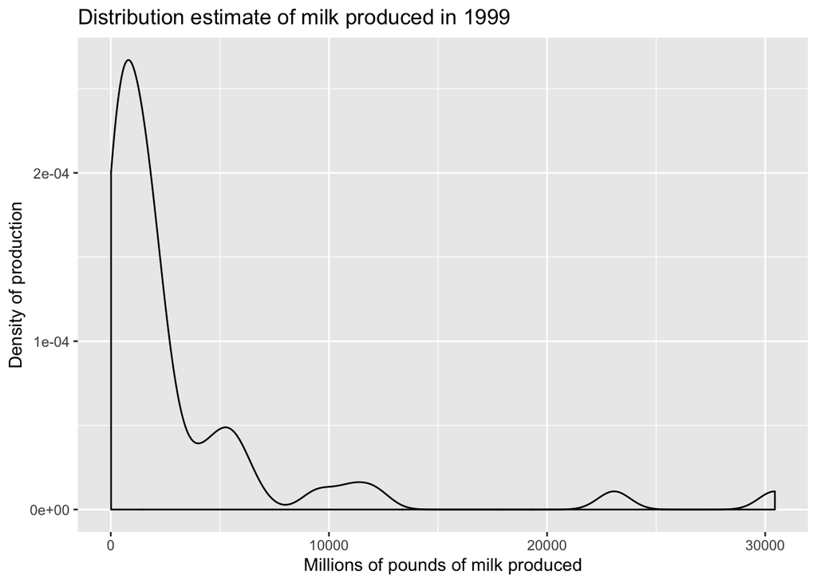

```r
milk99 <- milk %>%
  filter( year == 1999)
ggplot(data = milk99, aes(milk_million)) +
  geom_density()+
  ggtitle('Distribution estimate of milk produced in 1999') +
  theme_get()+
  xlab('Millions of pounds of milk produced') +
  ylab('Density of production')
```

```r
Average <- milk99 %>% group_by(state) %>% summarise(AVERAGE = mean(milk_million))
Median <- milk99 %>% group_by(state) %>% summarise(MEDIAN = median(milk_million))
Max <- milk99 %>% group_by(state) %>% arrange(desc(milk_million))
Min <- milk99 %>% group_by(state) %>% arrange(milk_million)

Average
```

```
## # A tibble: 50 x 2
##    state       AVERAGE
##    <fct>         <dbl>
##  1 Alabama         376
##  2 Alaska           14
##  3 Arizona        2931
##  4 Arkansas        520
##  5 California    30444
##  6 Colorado       1728
##  7 Connecticut     520
##  8 Delaware        145
##  9 Florida        2398
## 10 Georgia        1449
## # … with 40 more rows
```

```r
Median
```

```
## # A tibble: 50 x 2
##    state       MEDIAN
##    <fct>        <dbl>
##  1 Alabama        376
##  2 Alaska          14
##  3 Arizona       2931
##  4 Arkansas       520
##  5 California   30444
##  6 Colorado      1728
##  7 Connecticut    520
##  8 Delaware       145
##  9 Florida       2398
## 10 Georgia       1449
## # … with 40 more rows
```

```r
Max
```

```
## # A tibble: 50 x 5
## # Groups:   state [50]
##    region          state         year milk_produced milk_million
##    <fct>           <fct>        <dbl>         <dbl>        <dbl>
##  1 Pacific         California    1999   30444000000        30444
##  2 Lake States     Wisconsin     1999   23071000000        23071
##  3 Northeast       New York      1999   12082000000        12082
##  4 Northeast       Pennsylvania  1999   10931000000        10931
##  5 Lake States     Minnesota     1999    9478000000         9478
##  6 Mountain        Idaho         1999    6453000000         6453
##  7 Southern Plains Texas         1999    5620000000         5620
##  8 Pacific         Washington    1999    5535000000         5535
##  9 Lake States     Michigan      1999    5455000000         5455
## 10 Mountain        New Mexico    1999    4724000000         4724
## # … with 40 more rows
```

```r
Min
```

```
## # A tibble: 50 x 5
## # Groups:   state [50]
##    region      state           year milk_produced milk_million
##    <fct>       <fct>          <dbl>         <dbl>        <dbl>
##  1 Pacific     Alaska          1999      14000000           14
##  2 Northeast   Rhode Island    1999      31000000           31
##  3 Mountain    Wyoming         1999      80000000           80
##  4 Pacific     Hawaii          1999     120000000          120
##  5 Northeast   Delaware        1999     145000000          145
##  6 Appalachian West Virginia   1999     275000000          275
##  7 Northeast   New Jersey      1999     280000000          280
##  8 Mountain    Montana         1999     303000000          303
##  9 Northeast   New Hampshire   1999     321000000          321
## 10 Southeast   South Carolina  1999     369000000          369
## # … with 40 more rows
```

## The Distribution of the yearly milk production for 2000. (Logan)

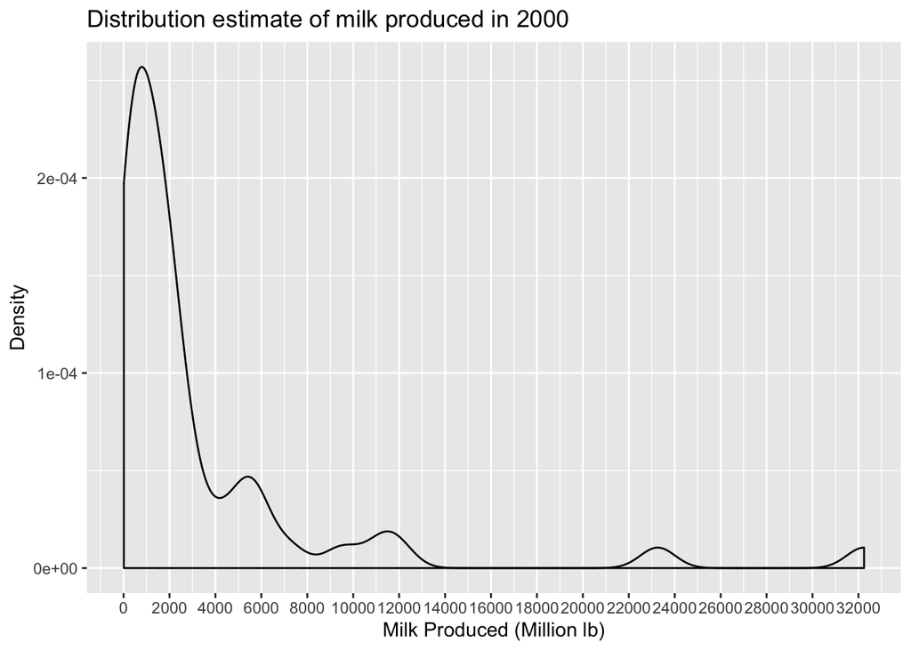

```r
milk2000 <- milk %>% filter(year == 2000)
ggplot(data = milk2000, aes(x = milk_million)) +
  geom_density() +
  scale_x_continuous(breaks = seq(0, 45000, 2000)) +
  labs(title = 'Distribution estimate of milk produced in 2000', x = "Milk Produced (Million lb)", y = "Density")
```

```r
milk2000.median = milk2000 %>% summarise(me = median(milk_million))
milk2000.mean = milk2000 %>% summarise(avg = mean(milk_million))
milk2000.max = milk2000 %>% summarise(max = max(milk_million)) #California
milk2000.min = milk2000 %>% summarise(max = min(milk_million)) #Alaska
```

**Findings:** In the year 2000, the mediam was 1.4535 billion pounds of milk. The average amount of milk produced was 3.334784 billion pounds of milk per state. California produced the most amount of milk, producing 32.245 billion pounds of milk. Alaska produced the least amount of milk, with only 13 million pounds of milk.

# Distribution of Milk Production for our State.

## Yearly Time Series for the Milk Production for Wisconsin (Trent)

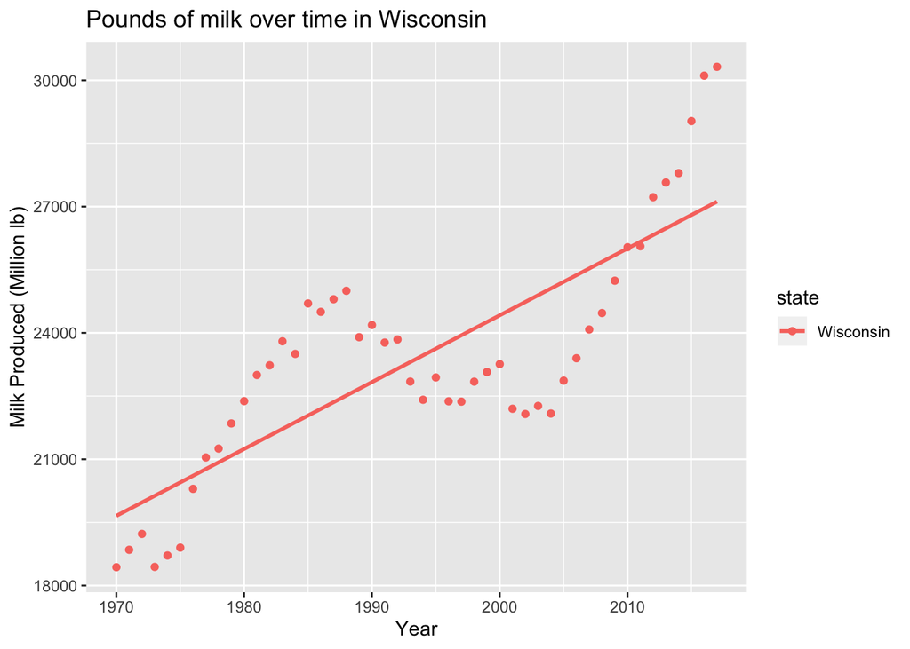

```r
milkWIS <- milk %>%
  filter(state %in% c('Wisconsin')) %>%
  select(state, year, milk_million)

ggplot(data = milkWIS, aes(x = year, y = milk_million, color = state)) +
  geom_point() +
  ggtitle('Pounds of milk over time in Wisconsin') +
  geom_smooth(method= "lm", na.rm = TRUE, se = FALSE) +
  xlab('Year') +
  ylab('Milk Produced (Million lb)')
```

**Findings:** This plot displays some interesting findings, predominantly the decline in milk production from the late 80’s to the mid 2000’s, followed by a sharp increase of milk production that we currently see. One of Wisconsin’s biggest exports is dairy products, so it is slightly puzzling for there to be such a significant dip.

## Yearly Time Series for the Milk Production for California (Logan)

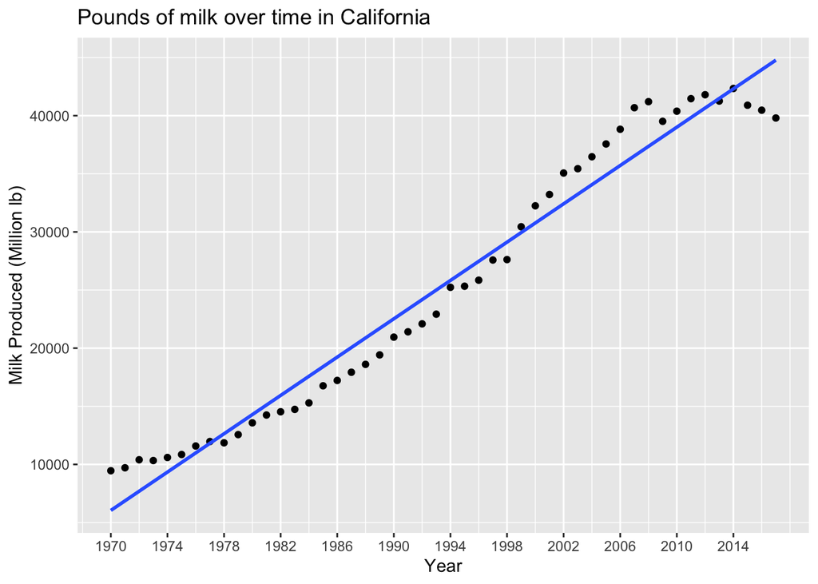

```r
milkCal <- milk %>%
  filter(state %in% c('California'))

ggplot(data = milkCal, aes(x = year, y = milk_million)) +
  geom_point() +
  ggtitle('Pounds of milk over time in California') +
  geom_smooth(method= "lm", na.rm = TRUE, se = FALSE) +
  labs(x = 'Year', y = 'Milk Produced (Million lb)') +
  scale_x_continuous(breaks = seq(1970, 2017, 4))
```

**Findings:** The plot above shows that California is constatly increasing between the years 1970 - 2008. In 2009 it is seen that there is a drop in milk production. After 2009, milk production is on the raise again until, 2014, were it seems that milk production is starting to decrease gradualy.

## Yearly Time Series for the Milk Production for Colorado (Tyler)

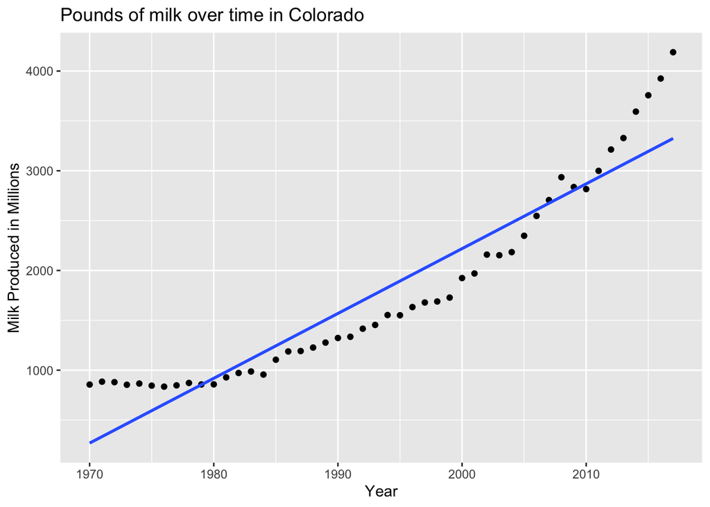

```r
milkCo <- milk %>%
  filter(state %in% c('Colorado'))

ggplot(data = milkCo, mapping = aes(x = year, y = milk_million)) +
  geom_point() +
  ggtitle('Pounds of milk over time in Colorado') +
  geom_smooth(method = "lm", na.rm = TRUE, se = FALSE) +
  xlab('Year') +
  ylab('Milk Produced in Millions')
```

**Findings** The plot shows that as the years go on that more and more milk was produced in Colorado. One year in particular, 2008, had a big surge in milk production. The years following had the production of milk decrease until 2011 where it started to rise again. For this plot, a linear model does not best fit the graph, a exponential fit would be better.

## Milk Production in New Mexico over Time (Joe)

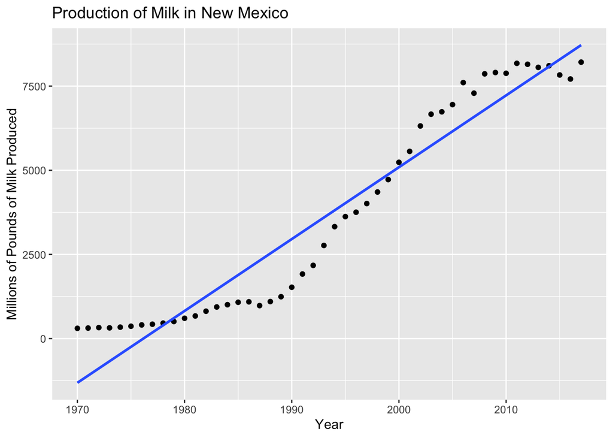

```r
MexMilk <- milk %>% filter(state %in% c('New Mexico'))

ggplot(data = MexMilk, aes(x= year, y= milk_million)) +
  geom_point()+
  geom_smooth(method= "lm", na.rm = TRUE, se = FALSE) +
  ggtitle('Production of Milk in New Mexico') +
  ylab('Millions of Pounds of Milk Produced') +
  xlab('Year')
```

## Yearly Time Series for the Milk Production for Georgia (Jack)

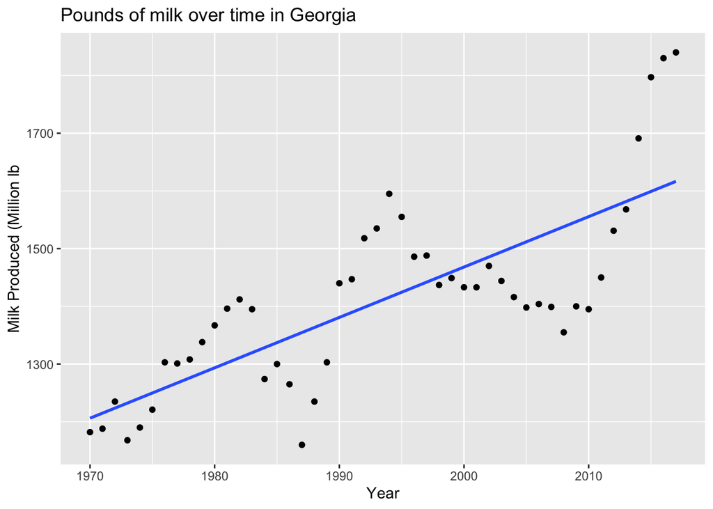

```r
milkGA <- milk %>%
  filter(state %in% c('Georgia'))

ggplot(data = milkGA, aes(x = year, y = milk_million)) +
  geom_point() +
  labs(title = "Pounds of milk over time in Georgia", x = "Year", y = "Milk Produced (Million lb") +
  geom_smooth(method = "lm", na.rm = TRUE, se = FALSE)
```

**Findings:** THis plot has some very interesting trends. There tends to be many ups and downs for Georgia’s milk production throughout the years. Although there has been an overall increase in teh amount of mike produced per year, there are serveral dips in the graph. One of those dips being between 1985-1999, and anther being 2005-2011. I know there was a significant drought in Georgia during the time perios and 2005-20011 wich could be a possivle confounding varibale.

## Milk production for Colorado, Georgia, New Mexico, California, Wisconsin. (TEAM)

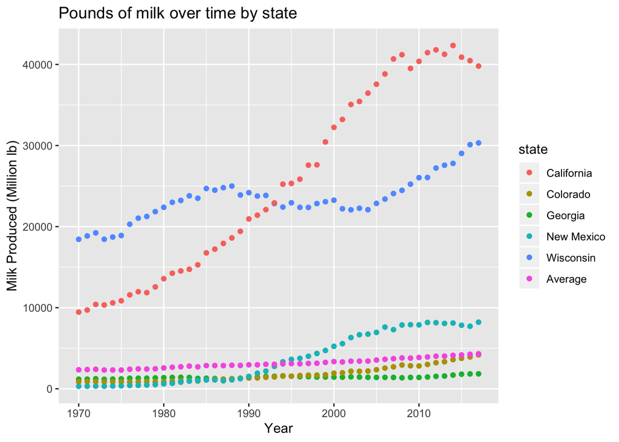

```r
milkAvg <- milk %>% group_by(year) %>% summarise(avg = mean(milk_produced), avg_million = mean(milk_million))
milkAvg <- unname(milkAvg)

milkState <- milk
for (row in 1:nrow(milkAvg)) {
  myYear <- milkAvg[row, 1]
  myAvg <- milkAvg[row, 2]
  myAvg_million <- milkAvg[row, 3]

  milkState <- rbind(milkState, data.frame(region = 'Average', state = 'Average', year = myYear, milk_produced = myAvg, milk_million = myAvg_million))
}

milksub <- milkState %>%
  filter(state %in% c('Colorado','Georgia','New Mexico','California','Wisconsin', 'Average')) %>%
  select(state, year, milk_million)

ggplot(data = milksub, aes(x = year, y = milk_million, color = state)) +
  geom_point() +
  labs(title = 'Pounds of milk over time by state', x = 'Year', y = 'Milk Produced (Million lb)')
```

# Stats for Milk production in United States.

## What year did the most amount of milk produced in the United States. (TEAM)

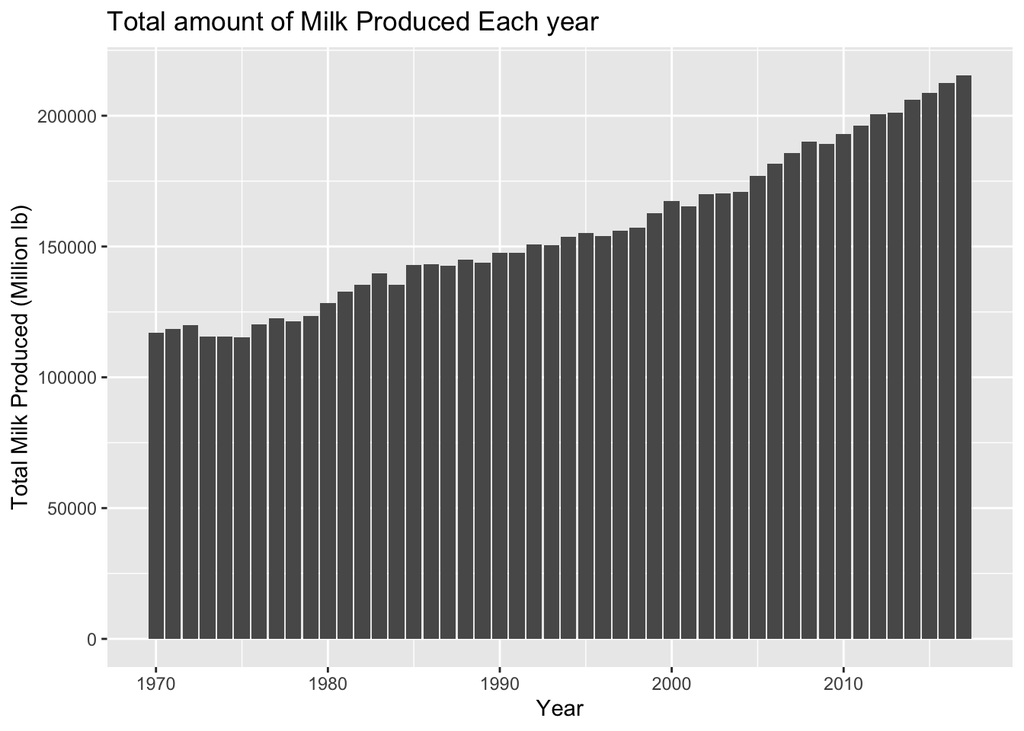

```r
milkTotal <- milk %>%
  group_by(year) %>%
  summarise(count = sum(milk_produced), count_million = sum(milk_million))

ggplot(data = milkTotal, aes(x = year, y = count_million)) + geom_col() + labs(title = "Total amount of Milk Produced Each year", x = "Year", y = "Total Milk Produced (Million lb)")
```

```r
milkTotal %>% arrange(desc(count_million))
```

```
## # A tibble: 48 x 3
##     year        count count_million
##    <dbl>        <dbl>         <dbl>
##  1  2017 215466000000        215466
##  2  2016 212406000000        212406
##  3  2015 208597000000        208597
##  4  2014 206056000000        206056
##  5  2013 201230000000        201230
##  6  2012 200642000000        200642
##  7  2011 196256000000        196256
##  8  2010 192876000000        192876
##  9  2008 189979000000        189979
## 10  2009 189202000000        189202
## # … with 38 more rows
```

## The year when the least milk was produced in the United States. (TEAM)

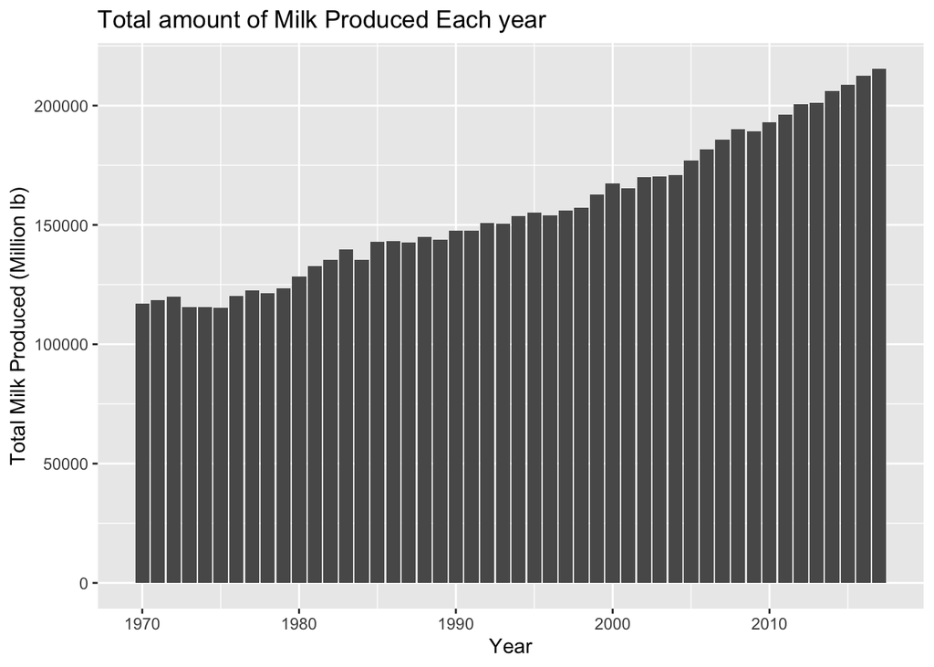

```r
milkTotal <- milk %>%
  group_by(year) %>%
  summarise(count = sum(milk_produced), count_million = sum(milk_million))

ggplot(data = milkTotal, aes(x = year, y = count_million)) + geom_col() + labs(title = "Total amount of Milk Produced Each year", x = "Year", y = "Total Milk Produced (Million lb)")
```

```r
milkTotal %>% arrange(count_million)
```

```
## # A tibble: 48 x 3
##     year        count count_million
##    <dbl>        <dbl>         <dbl>
##  1  1975 115398000000        115398
##  2  1973 115491000000        115491
##  3  1974 115586000000        115586
##  4  1970 117007000000        117007
##  5  1971 118566000000        118566
##  6  1972 120025000000        120025
##  7  1976 120180000000        120180
##  8  1978 121461000000        121461
##  9  1977 122654000000        122654
## 10  1979 123351000000        123351
## # … with 38 more rows
```

**Findings:** The year when the least amount of milk was prduced in the United States was 1975.

## In 2017, report the 5 states that produced the most milk. (TEAM)

```r
milkMost <- milk %>%
  filter(year == 2017) %>%
  group_by(state) %>%
  summarise(count = sum(milk_produced), countMil = sum(milk_million)) %>%
  arrange(desc(countMil))

milkMost
```

```
## # A tibble: 50 x 3
##    state              count countMil
##    <fct>              <dbl>    <dbl>
##  1 California   39798000000    39798
##  2 Wisconsin    30320000000    30320
##  3 New York     14912000000    14912
##  4 Idaho        14627000000    14627
##  5 Texas        12054000000    12054
##  6 Michigan     11231000000    11231
##  7 Pennsylvania 10938000000    10938
##  8 Minnesota     9864000000     9864
##  9 New Mexico    8212000000     8212
## 10 Washington    6526000000     6526
## # … with 40 more rows
```

**Findings:** The 5 states that produced the Most milk in 2017 were California, Wisconsin, New York, Idaho, and Texas

## In 2017, report the 5 states that produced the least milk. (TEAM)

```r
milkLeast <- milk %>%
  filter(year == 2017) %>%
  group_by(state) %>%
  summarise(count = sum(milk_produced), countMil = sum(milk_million)) %>%
  arrange(countMil)

milkLeast
```

```
## # A tibble: 50 x 3
##    state             count countMil
##    <fct>             <dbl>    <dbl>
##  1 Alaska          3000000        3
##  2 Rhode Island   13000000       13
##  3 Hawaii         39000000       39
##  4 Arkansas       79000000       79
##  5 Alabama        89000000       89
##  6 Delaware       93000000       93
##  7 New Jersey    119000000      119
##  8 West Virginia 127000000      127
##  9 Mississippi   137000000      137
## 10 Wyoming       138000000      138
## # … with 40 more rows
```

**Findings:** The 5 States that produced the least amount of milk in 2017 were Alaska, Rhode Island, Hawaii, Arkansas, and Alabama.

# Team Reports

**Trent:** I created the plot for the milk production in Wisconsin, as well as the data set for my birth year, 1998. I used the filter function to isolate just the 1998 data, and used a histogram to display the milk produced between all states. For the Wisconsin data, I used the filter function to isolate just Wisconsin’s data, and used the geometric point function to graph the findings. I also typed out the ethical discussion our group had about the findings from this data.

**Logan:** I created the plot for the milk prodcution stats for the year 2000 (my birth year). To do this I used the filter function, to filter out all years exept year 2000. Using this data I created a density plot for milk produced between all states. I then used the summerize mean, mediam, max, min functions to indetify the state that produced the most and least amount of milk, as well as how much most states produce, and the average amount of milk produced per state. I created the graph for the yearly production in California, (I have never lived their, but we needed more states). To create this graph I used filiter function to single out Califonia, then used a point graph to show the total milk produced for each year. I also used a smooth function to show the general trend of what the data is doing with the increase in year. I also created the graph for the year when the most amount of milk was produced in the United States.

**Jack:** I created the plot for the milk productin in Gerogia. For the Georgia plot I used the filter function to only utlize data from the state of georgia.

**Joe:** I created the plot for the milk production of the year I was born, 1999. I utilized the filter function to isolate the data that I wanted to work with, then used the density graph to show a general distribution of the aggregate milk production of all US states. I used the summarise function to find the Average and Median values of milk production separated by state. I also used the Arrange function to get an ascending and descending list of milk production. This makes the data extremely accessibly and easy to draw conclusions from. I also generated a graph for the yearly production of milk from New Mexico. I used a simple point graph and a line to match its general trend.

**Tyler:** I created the plot for the prodection of states milk in 1997(not my birth year, but didn’t want to do repeat graphs). For this I used the filter funtion to get the pecific yeat I wanted, and then used a density plot to report the findings. I also created the plot for the state of Colorado’s milk production over the years. To do this plot I filtered again, but this time to Colorado, and used a geom point plot to show the exact amount of milk produced per year, and then a smooth plot to get the overall trend of the data. Finally I found what states produced the most and least amount of milk in 2017. To do this I filtered by the year 2017 and grouped the data by state. Then I sumarised the data for a sum of all the milk produced by state and printed out the table in descending order and ascending order.

# Ethics of this data analysis.

The one major take away from this data is the steady rise of milk production across the United States, which means more and more dairy farms would need to have a larger stock of cows to produce the milk. This large demand of milk can lead to severe mistreatment of live stock, and higher demands could lead to worse conditions for the animals. So while humans may benefit from enjoying the wide variety of dairy products from the milk production industry, we must be mindful of the animals who make the milk, and treat them as ethically as possible.